# Code sessions - Machine learning supervisado

Carlos Daboín

2022-06-30

# El trade-off sesgo-varianza

Usaremos datos del paquete “[AmesHousing](https://cran.r-project.org/web/packages/AmesHousing/AmesHousing.pdf)” sobre el mercado immobiliario de Ames, ciudad del Estado Iowa. Contiene el precio de venta de casi 3.000 viviendas y 80 atributos de las mismas.

```r
# Data
ames <- make_ames()

#names(ames)

head(ames)
```

```
## # A tibble: 6 x 81
##   MS_SubClass      MS_Zoning     Lot_Frontage Lot_Area Street Alley   Lot_Shape
##   <fct>            <fct>                <dbl>    <int> <fct>  <fct>   <fct>
## 1 One_Story_1946_~ Residential_~          141    31770 Pave   No_All~ Slightly_~
## 2 One_Story_1946_~ Residential_~           80    11622 Pave   No_All~ Regular
## 3 One_Story_1946_~ Residential_~           81    14267 Pave   No_All~ Slightly_~
## 4 One_Story_1946_~ Residential_~           93    11160 Pave   No_All~ Regular
## 5 Two_Story_1946_~ Residential_~           74    13830 Pave   No_All~ Slightly_~
## 6 Two_Story_1946_~ Residential_~           78     9978 Pave   No_All~ Slightly_~
## # ... with 74 more variables: Land_Contour <fct>, Utilities <fct>,
## #   Lot_Config <fct>, Land_Slope <fct>, Neighborhood <fct>, Condition_1 <fct>,
## #   Condition_2 <fct>, Bldg_Type <fct>, House_Style <fct>, Overall_Qual <fct>,
## #   Overall_Cond <fct>, Year_Built <int>, Year_Remod_Add <int>,
## #   Roof_Style <fct>, Roof_Matl <fct>, Exterior_1st <fct>, Exterior_2nd <fct>,
## #   Mas_Vnr_Type <fct>, Mas_Vnr_Area <dbl>, Exter_Qual <fct>, Exter_Cond <fct>,
## #   Foundation <fct>, Bsmt_Qual <fct>, Bsmt_Cond <fct>, ...
```

En esta primera sección fijaremos dos modelos MCO en varias sub muestras de la data. En ambos casos, usaremos únicamente la información sobre pies cuadrados del primer piso de la propiedad para predecir el precio de venta.

Especificamente, el primer modelo será:

$$Y=\beta_{0}+\beta_{1} X+u$$

```r
# Dividir entre entrenamiento y evaluación ----

# Fijamos una semilla para que la aleatorizacion siempre nos devuelva los mismos resultados
set.seed(02138)

# usamos el paquete rsample para hacer una division 70% training -30% testing
split <- rsample::initial_split(ames, prop = 0.70)
ames_train <- rsample::training(split)
ames_test <- rsample::testing(split)
```

```r
# Hablemos de over-fitting ----

ames_train<-ames_train %>%
  # Cremos tres sub muestras
  mutate(random_id=runif(nrow(ames_train))) %>%
  mutate(muestra=case_when(random_id<0.33~1,
                           random_id>=0.33 &random_id <0.66~2,
                           random_id>=0.66 &random_id <1~3))

# Estimaremos dos modelos para cada sub-muestra y despues los testearemos en ames_test

i<-1 # esto no hace falta, es para explicarles mejor como funciona el for loop

model_reg<-list()
model_reg_poly<-list()

for (i in 1:3){

print(paste0("We're fitting the models for sample number ",i))

## Sepparate data into training and test
test <- subset(ames_train, muestra !=i )
train <- subset(ames_train, muestra == i)


model_reg[[i]] <- lm(Sale_Price ~  First_Flr_SF,
                     data=train)
model_reg_poly[[i]] <-lm(Sale_Price ~  First_Flr_SF +
                       I(First_Flr_SF^2)+
                       I(First_Flr_SF^3)+
                       I(First_Flr_SF^4)+
                       I(First_Flr_SF^5)+
                       I(First_Flr_SF^6),
                    data=train)

}
```

```
## [1] "We're fitting the models for sample number 1"
## [1] "We're fitting the models for sample number 2"
## [1] "We're fitting the models for sample number 3"
```

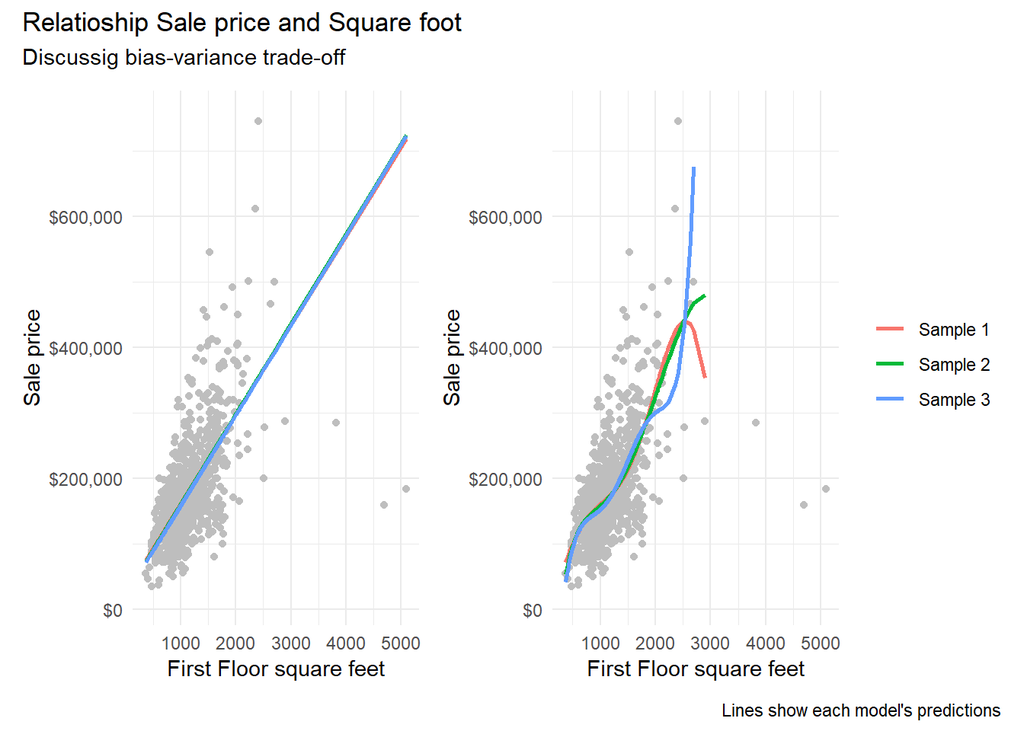

```r
## Inserta las predicciones de cada modelo en la data de testing

### Predicciones lineales
ames_test$pred_1<-predict(model_reg[[1]],newdata=ames_test)
ames_test$pred_2<-predict(model_reg[[2]],newdata=ames_test)
ames_test$pred_3<-predict(model_reg[[3]],newdata=ames_test)

### Predicciones polinomicas
ames_test$pred_poly_1<-predict(model_reg_poly[[1]],newdata=ames_test)
ames_test$pred_poly_2<-predict(model_reg_poly[[2]],newdata=ames_test)
ames_test$pred_poly_3<-predict(model_reg_poly[[3]],newdata=ames_test)


p2<-ggplot(data=ames_test, aes(y=Sale_Price,
                      x=First_Flr_SF))+
  geom_point(color="gray")+
  geom_line(aes(y=pred_1, color="Sample 1"), size=1)+
  geom_line(aes(y=pred_2, color="Sample 2"), size=1)+
  geom_line(aes(y=pred_3, color="Sample 3"), size=1)+
  scale_y_continuous(labels = scales::dollar,
                     limits = c(min(ames$Sale_Price),max(ames$Sale_Price)))+
  theme_minimal() +
  labs(y="Sale price",
       x="First Floor square feet",
       color=NULL)

p3<-ggplot(data=ames_test, aes(y=Sale_Price,
                      x=First_Flr_SF))+
  geom_point(color="gray")+
  geom_line(aes(y=pred_poly_1, color="Sample 1"), size=1)+
  geom_line(aes(y=pred_poly_2, color="Sample 2"), size=1)+
  geom_line(aes(y=pred_poly_3, color="Sample 3"), size=1)+
  scale_y_continuous(labels = scales::dollar,
                     limits = c(min(ames$Sale_Price),max(ames$Sale_Price)))+
  theme_minimal() +
  labs(y="Sale price",
       x="First Floor square feet",
       color=NULL)

# unificar graficos. Esto solo se puede hacer despues de ejecutar library(patchwork)
p2+p3+
  plot_layout(guides = "collect")+
  plot_annotation(title="Relatioship Sale price and Square foot",
                  subtitle = "Discussig bias-variance trade-off",
                  caption = "Lines show each model's predictions")
```

**Discutamos:**

¿Cuales modelos se ajustan mejor a la muestra con la que fueron estimados?

```r
ames_train %>%
  filter(muestra==2)%>%
  # creamos columnas con las predicciones de cada modelo (solo seleccionamos algunos)
  mutate(
    pred_simple = predict(model_reg[[2]], newdata=subset(ames_train,muestra==2)),
    pred_poly = predict(model_reg_poly[[2]], newdata=subset(ames_train,muestra==2))
  ) %>%
  # creamos la variable RMSE. Fijate que usamos summarise porque es un calculo agregado sobre todos los datos. Es sencillo, pero ojo con los parentesis.
  summarise(mean_sales_price=mean(Sale_Price),
            rmse_simple=sqrt(mean((Sale_Price-pred_simple)^2)),
            rmse_poly=sqrt(mean((Sale_Price-pred_poly)^2)))
```

```
## # A tibble: 1 x 3
##   mean_sales_price rmse_simple rmse_poly
##              <dbl>       <dbl>     <dbl>
## 1          185431.      60282.    58932.
```

¿Cuales modelos escogerías para hacer predicciones afuera de la muestra con la que fue estimado?

```r
ames_test %>%
  mutate(
    pred_simple = predict(model_reg[[2]], newdata=ames_test),
    pred_poly = predict(model_reg_poly[[2]], newdata=ames_test)
  ) %>%
  # creamos la variable RMSE. Fijate que usamos summarise porque es un calculo agregado sobre todos los datos. Es sencillo, pero ojo con los parentesis.
  summarise(mean_sales_price=mean(Sale_Price),
            rmse_simple=sqrt(mean((Sale_Price-pred_simple)^2)),
            rmse_poly=sqrt(mean((Sale_Price-pred_poly)^2)))
```

```
## # A tibble: 1 x 3
##   mean_sales_price rmse_simple rmse_poly
##              <dbl>       <dbl>     <dbl>
## 1          177811.      65301.   425336.
```

¿Cuales modelos tienen mas sesgo? ¿Cuales modelos tiene mas varianza?

# Regularización para evitar el sobreajuste

Vimos que modelos complejos logran reducir el sesgo a cambio de un incremento de la varianza. Esto nos impone restricciones a la hora de predecir el precio de ventas de los immuebles: Si añado todas las variables que se me ocurran en el modelo, tendré un modelo con una varianza entre muestras muy alta, que terminará siendo inútil.

Los métodos de regularización, entre los cuales destaca el método LASSO (least absolute shrinkage and selection operator), pueden ayudarnos a minimizar el sobre-ajuste de nuestros modelos interviniendo en el proceso de selección variables.

```r
# Splitting ----
## Segmentaremos la data en 70%-30%
## Esta vez usaremos las funciones del paquete rsample::
set.seed(02138)

split <- rsample::initial_split(ames, prop = 0.70)
ames_train <- rsample::training(split)
ames_test <- rsample::testing(split)

# Pre-processing -----
# Debemos normalizar las variables que queremos que esten en el modelo. En este caso, implica ponerlas en un formato matricial especial.
# Recuerda que los [] son para seleccionar componentes de distintos objetos en R.
# Genericamente matriz[1:3,1:2] un comando asi te devolvera las 3 perimeras filas y las 2 primeras columnas de una matriz
# glmnet::
X_train <- model.matrix(Sale_Price ~ ., data = ames_train)[, -1]
y_train <- ames_train$Sale_Price


# LASSO -----
fit_lasso <- glmnet::cv.glmnet(x = X_train, y = y_train,
                       alpha = 1, nfolds = 10)
```

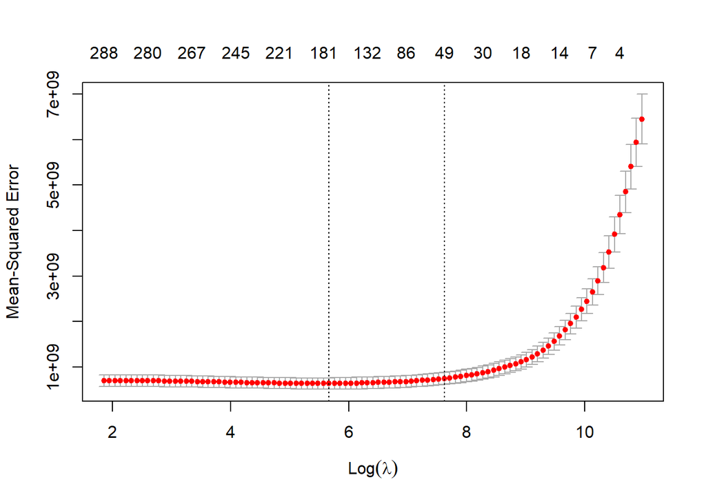

```r
# LASSO OUTPUTS ---
# Paremos un segundo para ver que es esto ?cv.glmnet

# Grafico
plot(fit_lasso) # Eje x muestra todos los lamba simulados, y es el MSE, arriba esta la cantidad de variables seleccionadas en cada modelo, la primera linea muestra el lamda de minimo MSE
```

```r
# Componentes
# este es un listado de la info contenida en el objeto fit_lasso
summary(fit_lasso)
```

```
##            Length Class  Mode
## lambda     99     -none- numeric
## cvm        99     -none- numeric
## cvsd       99     -none- numeric
## cvup       99     -none- numeric
## cvlo       99     -none- numeric
## nzero      99     -none- numeric
## call        5     -none- call
## name        1     -none- character
## glmnet.fit 12     elnet  list
## lambda.min  1     -none- numeric
## lambda.1se  1     -none- numeric
## index       2     -none- numeric
```

```r
# Resultados
# asi podemos extraer un data.frame con los coeficientes resultantes de la mejor estimacion
chosen_variables<-enframe(glmnet::coef.glmnet(fit_lasso, s="lambda.min")[,1])
head(chosen_variables)
```

```
## # A tibble: 6 x 2
##   name                                                  value
##   <chr>                                                 <dbl>
## 1 (Intercept)                                       -3783150.
## 2 MS_SubClassOne_Story_1945_and_Older                      0
## 3 MS_SubClassOne_Story_with_Finished_Attic_All_Ages     8262.
## 4 MS_SubClassOne_and_Half_Story_Unfinished_All_Ages     3347.
## 5 MS_SubClassOne_and_Half_Story_Finished_All_Ages          0
## 6 MS_SubClassTwo_Story_1946_and_Newer                      0
```

```r
chosen_variables %>%
  filter(value!=0)
```

```
## # A tibble: 177 x 2
##    name                                                     value
##    <chr>                                                    <dbl>
##  1 (Intercept)                                          -3783150.
##  2 MS_SubClassOne_Story_with_Finished_Attic_All_Ages        8262.
##  3 MS_SubClassOne_and_Half_Story_Unfinished_All_Ages        3347.
##  4 MS_SubClassTwo_Story_1945_and_Older                      2231.
##  5 MS_SubClassSplit_or_Multilevel                           -566.
##  6 MS_SubClassDuplex_All_Styles_and_Ages                  -18433.
##  7 MS_SubClassOne_Story_PUD_1946_and_Newer                 -7419.
##  8 MS_SubClassOne_and_Half_Story_PUD_All_Ages             -21034.
##  9 MS_SubClassTwo_Story_PUD_1946_and_Newer                -11728.
## 10 MS_SubClassTwo_Family_conversion_All_Styles_and_Ages    -6761.
## # ... with 167 more rows
```

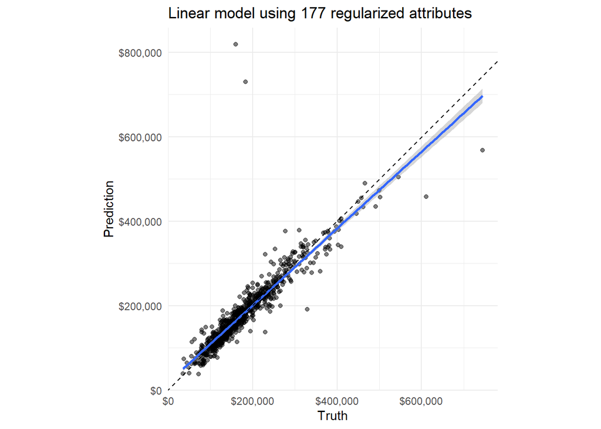

```r
# Prediction -----
X_test <- model.matrix(Sale_Price ~ ., data = ames_test)[, -1]

predictions_lasso<-predict(fit_lasso, newx = X_test,  s = "lambda.min") # fijate que predict es una funcion que cambia sus argumentos en funcion del tipo objeto sobre el que se aplica


ames_test %>%
  mutate(
    pred_lasso = as.vector(predictions_lasso)
  ) %>%
  ggplot(aes(x = Sale_Price, y = pred_lasso)) +
  geom_point(alpha = 0.5) +
  geom_smooth(method = "lm")+
  geom_abline(intercept = 0, slope = 1, linetype = "dashed") +
  scale_x_continuous(labels = scales::dollar) +
  scale_y_continuous(labels = scales::dollar) +
  coord_equal() +
  theme_minimal() +
  labs(title = paste0("Linear model using ",
                      nrow(filter(chosen_variables,value!=0)),
                      " regularized attributes"),
       x = "Truth",
       y = "Prediction")
```

## ¿En que se parecen LASSO, RIDGE, y MCO?

Funciones objetivo de OLS, LASSO, y RIDGE (las que hay que minimizar)

| MCO | RIDGE | LASSO |
| --- | --- | --- |
| $\ \underbrace{\sum_{i=1}^{n}\left(y_{i}-\beta_{0}-\sum_{j=1}^{p} \beta_{j} x_{i j}\right)^{2}}_{\text {Loss function }}$ | $Loss function+\underbrace{\lambda \sum_{j=1}^{p}\beta_{j}^2}_{\text {Regularizer }}$ | $Loss function+\underbrace{\lambda \sum_{j=1}^{p}\|\beta_{j}\|}_{\text {Regularizer }}$ |

```r
# Ridge -----
# simplemente modifica el valor de alpha a cero
fit_ridge <- cv.glmnet(x = X_train, y = y_train,
                       alpha = 0, nfolds = 10)

# MCO ------
# simplemente modifica el valor de lamda a cero: No habra penalidad adicional en la minimizacion de errores al cuadrado
fit_mco <- glmnet(x = X_train, y = y_train, lambda = 0)
```

Comparemos estas predicciones con las predicciones del LASSO

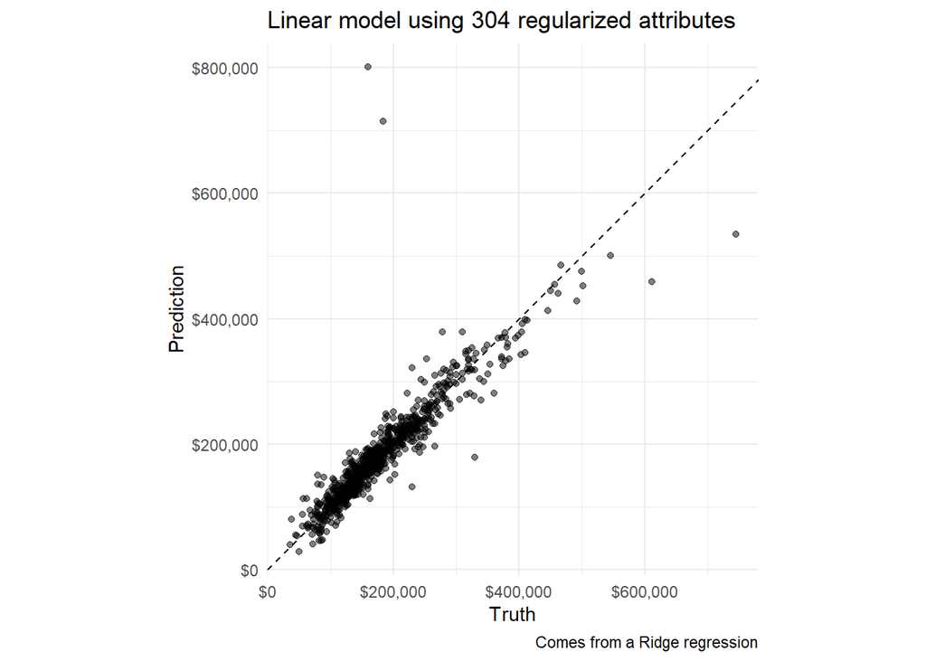

```r
ames_test %>%
  mutate(
    pred_ridge = as.vector(predict(fit_ridge, newx = X_test,  s = "lambda.min"))
  ) %>%
  ggplot(aes(x = Sale_Price, y = pred_ridge)) +
  geom_point(alpha = 0.5) +
  geom_abline(intercept = 0, slope = 1, linetype = "dashed") +
  scale_x_continuous(labels = scales::dollar) +
  scale_y_continuous(labels = scales::dollar) +
  coord_equal() +
  theme_minimal() +
  labs(title = paste0("Linear model using ",
                      nrow(filter(
                        enframe(glmnet::coef.glmnet(fit_ridge, s="lambda.min")[,1]),value!=0)),
                      " regularized attributes"),
       x = "Truth",
       y = "Prediction",
       caption = "Comes from a Ridge regression")
```

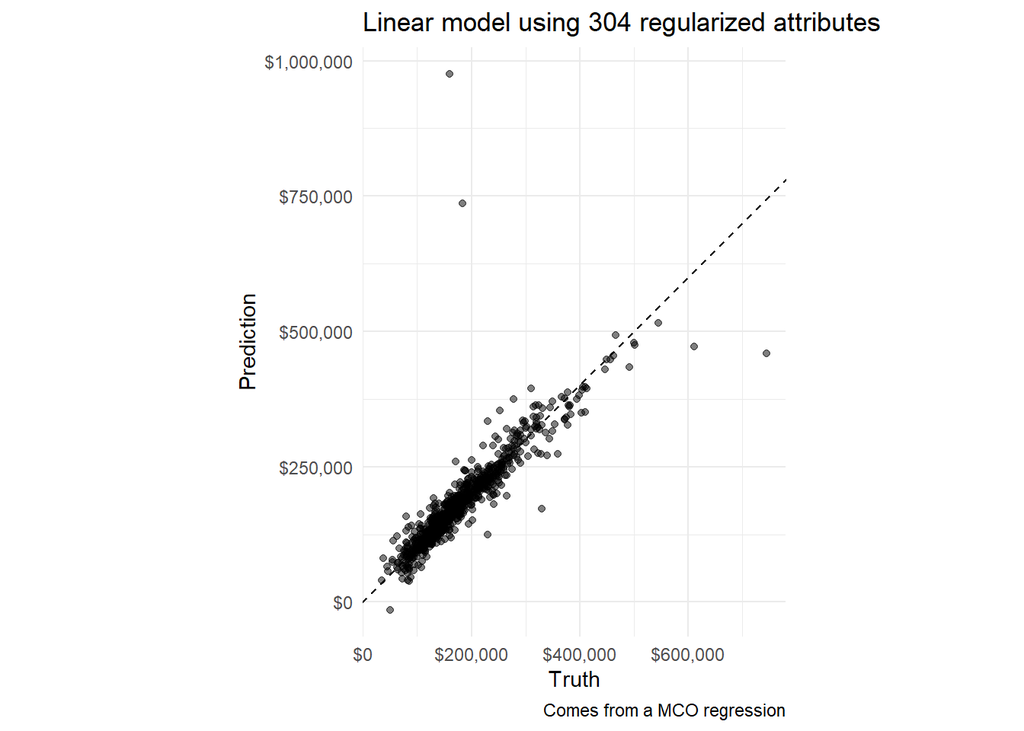

```r
ames_test %>%
  mutate(
    pred_mco = as.vector(predict(fit_mco, newx = X_test,  s = "lambda.min"))
  ) %>%
  ggplot(aes(x = Sale_Price, y = pred_mco)) +
  geom_point(alpha = 0.5) +
  geom_abline(intercept = 0, slope = 1, linetype = "dashed") +
  scale_x_continuous(labels = scales::dollar) +
  scale_y_continuous(labels = scales::dollar) +
  coord_equal() +
  theme_minimal() +
  labs(title = paste0("Linear model using ",
                      nrow(filter(
                        enframe(glmnet::coef.glmnet(fit_mco, s="lambda.min")[,1]),value!=0)),
                      " regularized attributes"),
       x = "Truth",
       y = "Prediction",
       caption = "Comes from a MCO regression")
```

Cuatifiquemos las diferencias en capacidad predictiva con el RMSE (Root mean squared error):

$$R M S E=\sqrt{\frac{1}{N}
\sum_{i=1}^{N}\left(y_{i}-\hat{y}_{i}\right)^{2}}$$

```r
ames_test %>%
  # creamos columnas con las predicciones de cada modelo (solo seleccionamos algunos)
  mutate(
    pred_lasso = as.vector(predictions_lasso),
    pred_ridge = as.vector(predict(fit_ridge, newx = X_test,  s = "lambda.min")),
    pred_mco = as.vector(predict(fit_mco, newx = X_test,  s = "lambda.min")),
    pred_simple = predict(model_reg[[2]], newdata=ames_test),
    pred_poly = predict(model_reg_poly[[2]], newdata=ames_test)
  ) %>%
  # creamos la variable RMSE. Fijate que usamos summarise porque es un calculo agregado sobre todos los datos. Es sencillo, pero ojo con los parentesis.
  summarise(mean_sales_price=mean(Sale_Price),
            rmse_lasso=sqrt(mean((Sale_Price-pred_lasso)^2)),
            rmse_ridge=sqrt(mean((Sale_Price-pred_ridge)^2)),
            rmse_mco=sqrt(mean((Sale_Price-pred_mco)^2)),
            rmse_simple=sqrt(mean((Sale_Price-pred_simple)^2)),
            rmse_poly=sqrt(mean((Sale_Price-pred_poly)^2)))
```

```
## # A tibble: 1 x 6
##   mean_sales_price rmse_lasso rmse_ridge rmse_mco rmse_simple rmse_poly
##              <dbl>      <dbl>      <dbl>    <dbl>       <dbl>     <dbl>
## 1          177811.     35988.     36036.   41070.      65301.   425336.
```

```r
#
```

# La semana que viene

Pasaremos de discutir predicción en **regresión** a discutir predicción en **clasificación**.

Ya no será ¿Qué atributos predicen mejor el precio de venta de la casa? sino ¿Qué atributos predicen mejor que una casa sea vendida en mas de US$ 250.000 ?

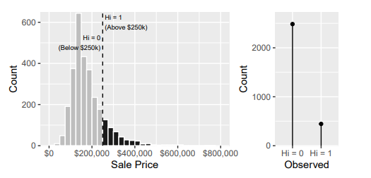

Creamos una variable que sea igual a 1 cuando Y>250.000

Tentativamente, cubriremos los siguientes temas.

- Regresión logística.
- Aplicaciones de LASSO en problemas de clasificación.
- Arboles de decisión.
- Random Forest.

## Enlaces de interés

[Kaggle.com](https://www.kaggle.com/): Concursos, data-sets y foros, relacionados a Machine Learning.

[Opportunity insigths:](https://opportunityinsights.org/) Datos del atlas de oportunidad, proyecto del profesor Raj Chetty sobre movilidad social con big data.

[Atlas de complejidad económica](https://atlas.cid.harvard.edu/) y [Metroverse](https://metroverse.cid.harvard.edu/): Acercamiento a los determinantes del crecimiento económico (y el cambio estructural) a partir de la aplicación de Machine Learning sobre datos de exportaciones y empleo.